# 4.1.1_Classification-Regression-Trees_SCOTUS

```python
from __future__ import division
import numpy as np
import pandas as pd
#import matplotlib as mpl
#import matplotlib.pyplot as plt
#%matplotlib inline
##plt.rcParams['figure.figsize'] = (15, 5)
#plt.style.use('ggplot')
```

```python
# This function creates images of tree models using pydot
import pydot
from StringIO import StringIO
from sklearn.tree import export_graphviz
from IPython.display import Image

def print_tree(estimator, features, class_names=None, filled=True):
    tree = estimator
    names = features
    color = filled
    classn = class_names

    dot_data = StringIO()
    export_graphviz(estimator, out_file=dot_data, feature_names=features, class_names=classn, filled=filled)
    graph = pydot.graph_from_dot_data(dot_data.getvalue())
    return(graph)
```

```python
stevens = pd.read_csv('../data/stevens.csv')
#stevens.info()
#stevens.head()
```

```python
# need to convert columns 2-7 to categorical with factors
scotusCategoricalIndex = {}
for i in stevens.columns[2:7]:
    temp = stevens.loc[:,i].factorize()
    stevens.loc[:,i] = temp[0]
    scotusCategoricalIndex[i] = temp[1]
```

```python
stevens.head()
```

|  | Docket | Term | Circuit | Issue | Petitioner | Respondent | LowerCourt | Unconst | Reverse |
| --- | --- | --- | --- | --- | --- | --- | --- | --- | --- |
| 0 | 93-1408 | 1994 | 0 | 0 | 0 | 0 | 0 | 0 | 1 |
| 1 | 93-1577 | 1994 | 1 | 0 | 0 | 0 | 0 | 0 | 1 |
| 2 | 93-1612 | 1994 | 2 | 0 | 0 | 0 | 0 | 0 | 1 |
| 3 | 94-623 | 1994 | 3 | 0 | 0 | 0 | 1 | 0 | 1 |
| 4 | 94-1175 | 1995 | 4 | 1 | 0 | 0 | 1 | 0 | 1 |

```python
# investigate possible 1-1 correlations between explanatory & responce variables
cm = stevens.corr()
cm[(cm > 0.2) & (cm != 1) ]
```

|  | Term | Circuit | Issue | Petitioner | Respondent | LowerCourt | Unconst | Reverse |
| --- | --- | --- | --- | --- | --- | --- | --- | --- |
| Term | NaN | NaN | NaN | NaN | NaN | NaN | NaN | NaN |
| Circuit | NaN | NaN | NaN | NaN | NaN | NaN | NaN | NaN |
| Issue | NaN | NaN | NaN | NaN | NaN | NaN | NaN | NaN |
| Petitioner | NaN | NaN | NaN | NaN | NaN | NaN | NaN | NaN |
| Respondent | NaN | NaN | NaN | NaN | NaN | 0.240091 | 0.301740 | NaN |
| LowerCourt | NaN | NaN | NaN | NaN | 0.240091 | NaN | 0.241961 | 0.334063 |
| Unconst | NaN | NaN | NaN | NaN | 0.301740 | 0.241961 | NaN | NaN |
| Reverse | NaN | NaN | NaN | NaN | NaN | 0.334063 | NaN | NaN |

```python
# investigate possible  multi-collinearity between explanatory variables
cm = stevens.iloc[:,:-1].corr()
cm[(cm > 0.5) & (cm != 1)].any().value_counts()
```

```
False    7
dtype: int64
```

```python
# split dataset into tran/ test sets , while maintaining the distribution found in the original Reverse.
from sklearn.cross_validation import StratifiedShuffleSplit as sss

index = sss(stevens['Reverse'], n_iter=1, test_size=0.30, random_state=0)
for train_index, test_index in index:
    stevensTrain = stevens.iloc[train_index,:]
    stevensTest = stevens.iloc[test_index,:]

X_train = stevensTrain.iloc[:,2:-1]
y_train_actual = stevensTrain.iloc[:,-1]
X_test = stevensTest.iloc[:,2:-1]
y_test_actual = stevensTest.iloc[:,-1]
```

```python
# simple Decision Tree
from sklearn.tree import DecisionTreeClassifier as DTC

regTree = DTC(min_samples_split=20, min_samples_leaf=5, random_state=1024)
regTree.fit(X_train, y_train_actual)
```

```
DecisionTreeClassifier(class_weight=None, criterion='gini', max_depth=None,
            max_features=None, max_leaf_nodes=None, min_samples_leaf=5,
            min_samples_split=20, min_weight_fraction_leaf=0.0,
            presort=False, random_state=1024, splitter='best')
```

```python
# "Gini importance" of each feature: the (normalized) total reduction of error brought by that feature
pd.DataFrame({'feature':X_train.columns, 'importance':regTree.feature_importances_})
```

|  | feature | importance |
| --- | --- | --- |
| 0 | Circuit | 0.240240 |
| 1 | Issue | 0.102193 |
| 2 | Petitioner | 0.094417 |
| 3 | Respondent | 0.253660 |
| 4 | LowerCourt | 0.277206 |
| 5 | Unconst | 0.032284 |

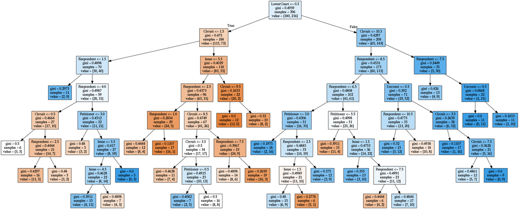

```python
# visualize the decision tree
graph = print_tree(regTree, stevensTrain.columns[2:8])
Image(graph.create_png())
```

### Model Evaluation

```python
from sklearn.metrics import accuracy_score
# accuracy_score = Proportion of correct predictions ; 'same' as F1-score

y_train_pred = regTree.predict(X_train)
accuracy_score(y_train_actual, y_train_pred)
```

```
0.74494949494949492
```

```python
from sklearn.metrics import accuracy_score
# accuracy_score = Proportion of correct predictions

y_test_pred = regTree.predict(X_test)
accuracy_score(y_test_actual, y_test_pred)
```

```
0.6705882352941176
```

### Use Cross-Validation to evaluate model accuracy

- **K** can be any number, but K=10 is generally recommended.
- For **classification** problems, `**stratified sampling` (via **StratifiedKFold**) is recommended for creating the folds.
  - Each response class should be represented with equal proportions in each of the K folds.
  - **scikit-learn**'s `cross_val_score` function does this by default.
    - When the **cv** argument is an integer, `cross_val_score` uses the **KFold or StratifiedKFold** strategies by default (depending on the absence or presence of the target array).

```python
# specify predictor/responce elements
X = stevens.iloc[:,2:-1]
y = stevens.iloc[:,-1]
```

```python
from sklearn.tree import DecisionTreeClassifier as DTC
from sklearn.cross_validation import cross_val_score

decTree = DTC(max_depth=2)
scores = cross_val_score(decTree, X, y, cv=10, scoring='accuracy')
#print scores

# use average accuracy as an estimate of out-of-sample accuracy
print scores.mean()
```

```
0.639951013898
```

```python
# search for an optimal value for one of the model's parameter, e.g. DecisionTreeClassifier(min_sample_split)
param_range = range(1,10)
p_scores = []
for p in param_range:
    decTree = DTC(max_depth=p)
    scores = cross_val_score(decTree, X, y, cv=10, scoring='accuracy')
    p_scores.append(scores.mean())
p_scores
```

```
[0.668368079289132,
 0.63995101389838238,
 0.64731544771018457,
 0.61146331738436999,
 0.56362838915470492,
 0.55558954203691047,
 0.55536796536796529,
 0.56586295283663701,
 0.56229152426520845]
```

```python
# RandomForestClassifier(n_estimators)
from sklearn.cross_validation import cross_val_score
from sklearn.ensemble import RandomForestClassifier as RFC

param_range = range(5,21,2)
p_scores = []
for p in param_range:
    rfc = RFC(n_estimators=p)
    scores = cross_val_score(rfc, X, y, cv=10, scoring='accuracy')
    p_scores.append(scores.mean())
p_scores
```

```
[0.54114262930052415,
 0.54302574618364086,
 0.53603839143312826,
 0.57830371383002965,
 0.55364718614718622,
 0.57651686033264971,
 0.56420483025746182,
 0.55016746411483253]
```

```python
# KNN (n_neighbors)
param_range = range(30, 52,2)
p_scores = []
for p in param_range:
    knn = KNeighborsClassifier(n_neighbors=p)
    scores = cross_val_score(knn, X, y, cv=10, scoring='accuracy')
    p_scores.append(scores.mean())
p_scores
```

```
[0.4845904534062429,
 0.49878332194121677,
 0.49336238323080428,
 0.49693381180223284,
 0.49862554112554108,
 0.47926349965823645,
 0.48270847573479153,
 0.46867338801549324,
 0.47399920255183414,
 0.47230861244019129,
 0.47584871269081785]
```

### Use Cross-Validation to evaluate the accuracies of different models

```python
from sklearn.cross_validation import cross_val_score
```

```python
# 10-fold cross-validation with the best KNearestNeighbors model
from sklearn.neighbors import KNeighborsClassifier

knn = KNeighborsClassifier(n_neighbors=38)
cross_val_score(knn, X, y, cv=10, scoring='accuracy').mean()
```

```
0.49862554112554108
```

```python
# 10-fold cross-validation with logistic regression
from sklearn.linear_model import LogisticRegression
logreg = LogisticRegression()
print(cross_val_score(logreg, X, y, cv=10, scoring='accuracy').mean())
```

```
0.668368079289
```

```python
# 10-fold cross-validation with Decision Trees with manually tuned features
from sklearn.tree import DecisionTreeClassifier as DTC
regTree = DTC(min_samples_split=20, min_samples_leaf=5, random_state=1024)
cross_val_score(regTree, X, y, cv=10, scoring='accuracy').mean()
```

```
0.53061631351105043
```

```python
# 10-fold cross-validation with Random Forests
from sklearn.ensemble import RandomForestClassifier as RFC
rfc = RFC(n_estimators=15)
cross_val_score(rfc, X, y, cv=10, scoring='accuracy').mean()
```

```
0.54863807245386198
```

```python
from sklearn.ensemble import VotingClassifier

mrc1 = VotingClassifier(estimators=[('rf', rfc), ('dt', regTree), ('logit', logreg)], voting='hard', weights=[1,1,2])
cross_val_score(mrc1, X, y, cv=10, scoring='accuracy').mean()
```

```
0.62970893141945772
```

### Using Cross-Validation & GridSearch for Efficient Discovery of optimal tuning parameters

```python
from sklearn.grid_search import GridSearchCV
from sklearn.cross_validation import StratifiedKFold, cross_val_score

from sklearn.tree import DecisionTreeClassifier as DTC
from sklearn.ensemble import RandomForestClassifier as RFC
from sklearn.ensemble import ExtraTreesClassifier as ETC
```

```python
'''create a parameter grid ; this will be a Dict which maps the parameter names to the values to be searched. '''
# various param lists
range1 = range(1,10)
range2 = range(1,20,2)
range3 = range(5,20,2)
range4 = range(10,50,5)
range5 = [1,2]
range6 = range(10,32,2)

DTC_grid = dict(min_samples_split=range6, min_samples_leaf=range4)
RFC_grid = dict(n_estimators=range3, min_samples_split=range6, min_samples_leaf=range4)
ETC_grid = dict(n_estimators=range3, min_samples_split=range6, min_samples_leaf=range4)
```

```python
# instantiate the models & corresponding grids ; specify n_jobs=-1 for parallel computation
rfc = RFC()
dtc = DTC()
etc = ETC()

dtc_grid = GridSearchCV(dtc, DTC_grid, cv=10, scoring='accuracy', n_jobs = -1)
rfc_grid = GridSearchCV(rfc, RFC_grid, cv=10, scoring='accuracy', n_jobs = -1)
etc_grid = GridSearchCV(etc, ETC_grid, cv=10, scoring='accuracy', n_jobs = -1)
```

```python
# fit the Decision Tree grid with data
dtc_grid.fit(X, y)

# examine the best model
print(dtc_grid.best_score_)
print(dtc_grid.best_params_)
print(dtc_grid.best_estimator_)
```

```
0.637809187279
{'min_samples_split': 10, 'min_samples_leaf': 45}
DecisionTreeClassifier(class_weight=None, criterion='gini', max_depth=None,
            max_features=None, max_leaf_nodes=None, min_samples_leaf=45,
            min_samples_split=10, min_weight_fraction_leaf=0.0,
            presort=False, random_state=None, splitter='best')
```

```python
# fit the Random Forrest grid with data
rfc_grid.fit(X, y)

# examine the best model
print(rfc_grid.best_score_)
print(rfc_grid.best_params_)
print(rfc_grid.best_estimator_)
```

```
0.657243816254
{'min_samples_split': 18, 'n_estimators': 11, 'min_samples_leaf': 45}
RandomForestClassifier(bootstrap=True, class_weight=None, criterion='gini',
            max_depth=None, max_features='auto', max_leaf_nodes=None,
            min_samples_leaf=45, min_samples_split=18,
            min_weight_fraction_leaf=0.0, n_estimators=11, n_jobs=1,
            oob_score=False, random_state=None, verbose=0,
            warm_start=False)
```

```python
# fit the Extra Trees grid with data
etc_grid.fit(X, y)

# examine the best model
print(etc_grid.best_score_)
print(etc_grid.best_params_)
print(etc_grid.best_estimator_)
```

```
0.667844522968
{'min_samples_split': 16, 'n_estimators': 17, 'min_samples_leaf': 25}
ExtraTreesClassifier(bootstrap=False, class_weight=None, criterion='gini',
           max_depth=None, max_features='auto', max_leaf_nodes=None,
           min_samples_leaf=25, min_samples_split=16,
           min_weight_fraction_leaf=0.0, n_estimators=17, n_jobs=1,
           oob_score=False, random_state=None, verbose=0, warm_start=False)
```

### Gradient Boosting

- Rather than looking at 200 (say) parallel estimators, We construct a chain of 200 estimators which iteratively refine the results of the previous estimator.
- The idea is that by sequentially applying very fast, simple models, we can get a total model error which is better than any of the individual pieces.

```python
from sklearn.grid_search import GridSearchCV
from sklearn.ensemble import GradientBoostingClassifier as GBC

gbc = GBC()
#params = {'n_estimators':range(10,21,2), 'min_samples_split':range(5,32,2) , 'learning_rate':[0.05, 0.1, 0.15]}
params = {'n_estimators':[10], 'min_samples_leaf':range(10,50,5), 'min_samples_split':range(10,32,2)}
gbc_grid = GridSearchCV(gbc, params, cv=10, scoring='accuracy', n_jobs = -1)
gbc_grid.fit(X,y)

print(gbc_grid.best_score_)
print(gbc_grid.best_params_)
print(gbc_grid.best_estimator_)
```

```
0.651943462898
{'min_samples_split': 10, 'n_estimators': 10, 'min_samples_leaf': 15}
GradientBoostingClassifier(init=None, learning_rate=0.1, loss='deviance',
              max_depth=3, max_features=None, max_leaf_nodes=None,
              min_samples_leaf=15, min_samples_split=10,
              min_weight_fraction_leaf=0.0, n_estimators=10,
              presort='auto', random_state=None, subsample=1.0, verbose=0,
              warm_start=False)
```

### Closing Remarks

There is a problem with using the `grid.best_score_` score for evaluation, however.

You might be making what is called a **multiple hypothesis testing error**. If you try very many parameter settings, some of them will work better just by chance, and the score that you obtained might not reflect how your model would perform on new unseen data.

Therefore, it is good to **split off a separate test-set before performing grid-search**.

This pattern can be seen as a **training-validation-test split**, and is common in machine learning:

```
from sklearn.cross_validation import StratifiedShuffleSplit
#create train/test sets X_train, X_test, y_train, y_test

# run param grid search on training set
param_grid = {'C': [0.001, 0.01, 0.1, 1, 10], 'gamma': [0.001, 0.01, 0.1, 1]}
cv = KFold(n=len(X_train), n_folds=10, shuffle=True)

grid = GridSearchCV(SVR(), param_grid=param_grid, cv=cv)

# obtain accuracy on test set
grid.fit(X_train, y_train)
grid.score(X_test, y_test)
```